# Tugas Pertemuan 8

### Identifikasi Model

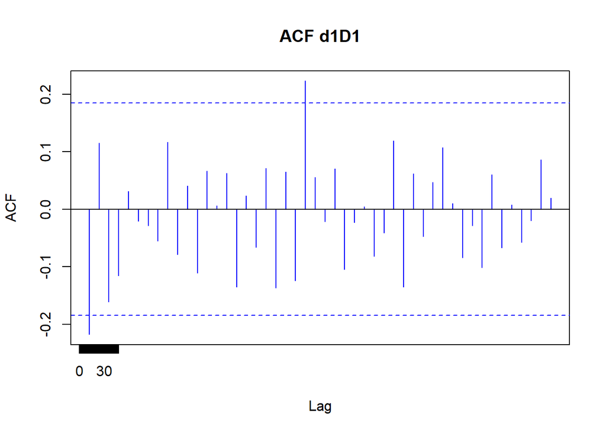

```r
acf3 <- acf(d1D1,lag.max=48,xaxt="n", main="ACF d1D1", col="blue")
axis(1, at=0:48/12, labels=0:48)
```

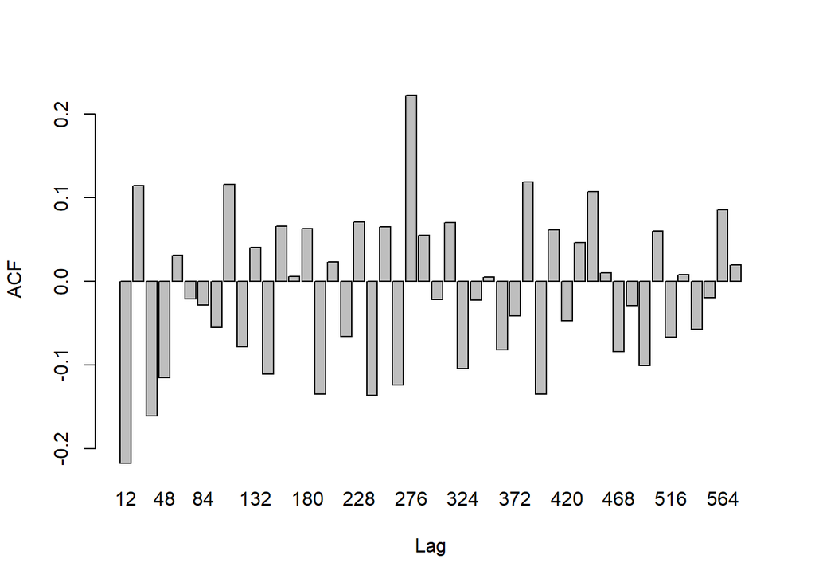

```r
acf3$lag <- acf3$lag * 12
acf3.1 <- as.data.frame(cbind(acf3$acf,acf3$lag))
acf3.2 <- acf3.1[which(acf3.1$V2%%12==0),]
barplot(height = acf3.2$V1, names.arg=acf3.2$V2, ylab="ACF",
xlab="Lag")
```

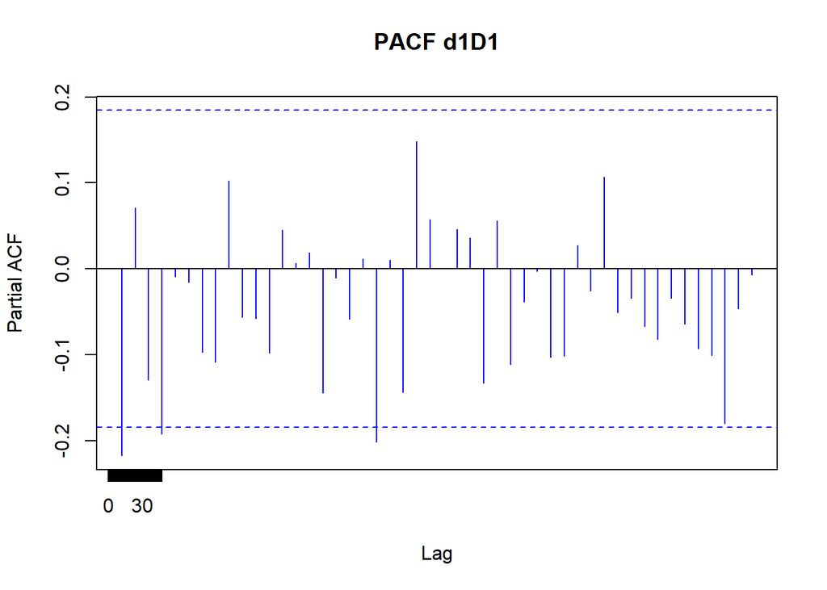

```r
pacf3 <- pacf(d1D1,lag.max=48,xaxt="n", main="PACF d1D1", col="blue")
axis(1, at=0:48/12, labels=0:48)
```

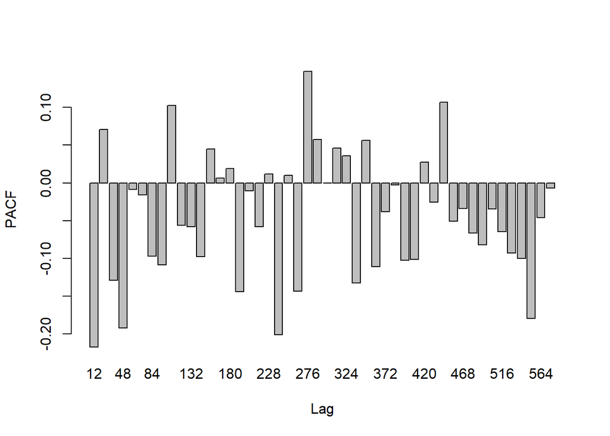

```r
pacf3$lag <- pacf3$lag * 12
pacf3.1 <- as.data.frame(cbind(pacf3$acf,pacf3$lag))
pacf3.2 <- pacf3.1[which(pacf3.1$V2%%12==0),]
barplot(height = pacf3.2$V1, names.arg=pacf3.2$V2, ylab="PACF", xlab="Lag")
```

Plot PACF contoh menunjukkan *cuts-off* pada lag-1 sehingga ordo *p*=1, sementara pada pola musimannya tidak terlihat model AR yang terbentuk karena cenderung *tails-off*.

**EACF**

```r
TSA::eacf(d1D1)
```

```
## AR/MA
##   0 1 2 3 4 5 6 7 8 9 10 11 12 13
## 0 x o o o o o o o o o o  o  o  o
## 1 x o o o o o o o o o o  o  o  o
## 2 x o o o o o o o o o o  o  o  o
## 3 x x x o o o o o o o o  o  o  o
## 4 o o x o o o o o o o o  o  o  o
## 5 x o o o o o o o o o o  o  o  o
## 6 o o o x o o o o o o o  o  o  o
## 7 x x o x o o x o o o o  o  o  o
```

### Pendugaan Parameter

```r
tmodel1 <- Arima(train.ts,order=c(0,1,1),seasonal=c(0,1,1))
summary(tmodel1)
```

```
## Series: train.ts
## ARIMA(0,1,1)
##
## Coefficients:
##          ma1
##       0.3429
## s.e.  0.0986
##
## sigma^2 = 782.7:  log likelihood = -593.35
## AIC=1190.69   AICc=1190.79   BIC=1196.35
##
## Training set error measures:
##                    ME     RMSE      MAE       MPE     MAPE      MASE
## Training set 2.207431 27.75336 21.88912 0.5237371 8.576003 0.9675177
##                     ACF1
## Training set -0.03271205
```

```r
lmtest::coeftest(tmodel1)
```

```
##
## z test of coefficients:
##
##     Estimate Std. Error z value  Pr(>|z|)
## ma1 0.342894   0.098637  3.4763 0.0005084 ***
## ---
## Signif. codes:  0 '***' 0.001 '**' 0.01 '*' 0.05 '.' 0.1 ' ' 1
```

```r
tmodel2 <- Arima(train.ts,order=c(1,1,1),seasonal=c(0,1,1))
summary(tmodel2)
```

```
## Series: train.ts
## ARIMA(1,1,1)
##
## Coefficients:
##           ar1     ma1
##       -0.5759  0.9296
## s.e.   0.1040  0.0553
##
## sigma^2 = 726.8:  log likelihood = -588.58
## AIC=1183.17   AICc=1183.36   BIC=1191.65
##
## Training set error measures:
##                    ME     RMSE     MAE       MPE     MAPE      MASE       ACF1
## Training set 2.345883 26.63622 21.1867 0.5662205 8.418494 0.9364703 0.03543661
```

```r
lmtest::coeftest(tmodel2)
```

```
##
## z test of coefficients:
##
##      Estimate Std. Error z value  Pr(>|z|)
## ar1 -0.575937   0.103953 -5.5404 3.019e-08 ***
## ma1  0.929634   0.055253 16.8250 < 2.2e-16 ***
## ---
## Signif. codes:  0 '***' 0.001 '**' 0.01 '*' 0.05 '.' 0.1 ' ' 1
```

```r
tmodel3 <- Arima(train.ts,order=c(2,1,1),seasonal=c(0,1,1))
summary(tmodel3)
```

```
## Series: train.ts
## ARIMA(2,1,1)
##
## Coefficients:
##          ar1      ar2     ma1
##       1.0429  -0.4253  -0.846
## s.e.  0.0885   0.0822   0.046
##
## sigma^2 = 698:  log likelihood = -585.46
## AIC=1178.92   AICc=1179.25   BIC=1190.23
##
## Training set error measures:
##                    ME     RMSE      MAE      MPE     MAPE      MASE        ACF1
## Training set 5.807504 25.99612 20.55182 1.804154 7.910448 0.9084077 -0.08476237
```

```r
lmtest::coeftest(tmodel3)
```

```
##
## z test of coefficients:
##
##      Estimate Std. Error  z value  Pr(>|z|)
## ar1  1.042895   0.088468  11.7883 < 2.2e-16 ***
## ar2 -0.425279   0.082245  -5.1709  2.33e-07 ***
## ma1 -0.845988   0.046000 -18.3912 < 2.2e-16 ***
## ---
## Signif. codes:  0 '***' 0.001 '**' 0.01 '*' 0.05 '.' 0.1 ' ' 1
```

```r
tmodel4 <- Arima(train.ts,order=c(3,1,0),seasonal=c(0,1,1))
summary(tmodel4)
```

```
## Series: train.ts
## ARIMA(3,1,0)
##
## Coefficients:
##          ar1      ar2      ar3
##       0.2886  -0.1394  -0.1068
## s.e.  0.0895   0.0921   0.0892
##
## sigma^2 = 779.9:  log likelihood = -592.13
## AIC=1192.25   AICc=1192.59   BIC=1203.57
##
## Training set error measures:
##                   ME    RMSE      MAE       MPE     MAPE      MASE        ACF1
## Training set 2.71253 27.4793 21.61785 0.6211696 8.447182 0.9555274 -0.03648994
```

```r
lmtest::coeftest(tmodel4)
```

```
##
## z test of coefficients:
##
##      Estimate Std. Error z value Pr(>|z|)
## ar1  0.288561   0.089469  3.2253 0.001258 **
## ar2 -0.139418   0.092108 -1.5136 0.130117
## ar3 -0.106796   0.089155 -1.1979 0.230969
## ---
## Signif. codes:  0 '***' 0.001 '**' 0.01 '*' 0.05 '.' 0.1 ' ' 1
```

```r
tmodel5 <- Arima(train.ts,order=c(3,1,1),seasonal=c(0,1,1))
summary(tmodel5)
```

```
## Series: train.ts
## ARIMA(3,1,1)
##
## Coefficients:
##          ar1      ar2      ar3      ma1
##       0.9903  -0.3304  -0.0951  -0.8302
## s.e.  0.1017   0.1243   0.0940   0.0502
##
## sigma^2 = 697.6:  log likelihood = -584.96
## AIC=1179.91   AICc=1180.42   BIC=1194.05
##
## Training set error measures:
##                    ME     RMSE      MAE      MPE     MAPE      MASE        ACF1
## Training set 5.972775 25.88295 20.15479 1.882303 7.747957 0.8908588 -0.06674592
```

```r
lmtest::coeftest(tmodel5)
```

```
##
## z test of coefficients:
##
##      Estimate Std. Error  z value  Pr(>|z|)
## ar1  0.990261   0.101655   9.7414 < 2.2e-16 ***
## ar2 -0.330423   0.124265  -2.6590  0.007837 **
## ar3 -0.095061   0.093958  -1.0117  0.311666
## ma1 -0.830231   0.050212 -16.5344 < 2.2e-16 ***
## ---
## Signif. codes:  0 '***' 0.001 '**' 0.01 '*' 0.05 '.' 0.1 ' ' 1
```

```r
AICKandidatModel <- c(tmodel1$aic, tmodel2$aic, tmodel3$aic,
                      tmodel4$aic, tmodel5$aic)
AICcKandidatModel <- c(tmodel1$aicc, tmodel2$aicc, tmodel3$aicc,
                       tmodel4$aicc, tmodel5$aicc)
BICKandidatModel <- c(tmodel1$bic, tmodel2$bic, tmodel3$bic,
                      tmodel4$bic, tmodel5$bic)
KandidatModelARIMA <- c("ARIMA(0,1,1)(0,1,1)12", "ARIMA(1,1,1)(0,1,1)12",
                        "ARIMA(2,1,0)(0,1,1)12", "ARIMA(3,1,0)(0,1,1)12",
                        "ARIMA(3,1,2)(0,1,1)12")
compmodelARIMA <- cbind(KandidatModelARIMA, AICKandidatModel,
                        AICcKandidatModel, BICKandidatModel)
colnames(compmodelARIMA) <- c("Kandidat Model", "Nilai AIC",
                              "Nilai AICc", "Nilai BIC")
compmodelARIMA <- as.data.frame(compmodelARIMA)
compmodelARIMA
```

[output not shown]

```r
model.auto.arima <- auto.arima(train.ts)
summary(model.auto.arima)
```

```
## Series: train.ts
## ARIMA(4,1,3)
##
## Coefficients:
##           ar1     ar2     ar3      ar4     ma1      ma2      ma3
##       -0.5361  0.4554  0.1810  -0.4893  0.8684  -0.5614  -0.7095
## s.e.   0.0957  0.1111  0.1017   0.0931  0.0875   0.0933   0.0655
##
## sigma^2 = 587.6:  log likelihood = -573.59
## AIC=1163.18   AICc=1164.42   BIC=1185.81
##
## Training set error measures:
##                    ME     RMSE      MAE      MPE     MAPE      MASE       ACF1
## Training set 5.383514 23.45913 18.00596 1.760747 7.120466 0.7958788 -0.0615248
```

```r
lmtest::coeftest(model.auto.arima)
```

```
##
## z test of coefficients:
##
##      Estimate Std. Error  z value  Pr(>|z|)
## ar1 -0.536088   0.095723  -5.6004 2.138e-08 ***
## ar2  0.455416   0.111094   4.0994 4.142e-05 ***
## ar3  0.181043   0.101710   1.7800   0.07508 .
## ar4 -0.489284   0.093141  -5.2532 1.495e-07 ***
## ma1  0.868387   0.087511   9.9232 < 2.2e-16 ***
## ma2 -0.561360   0.093282  -6.0179 1.767e-09 ***
## ma3 -0.709492   0.065502 -10.8316 < 2.2e-16 ***
## ---
## Signif. codes:  0 '***' 0.001 '**' 0.01 '*' 0.05 '.' 0.1 ' ' 1
```

### Diagnostik Model

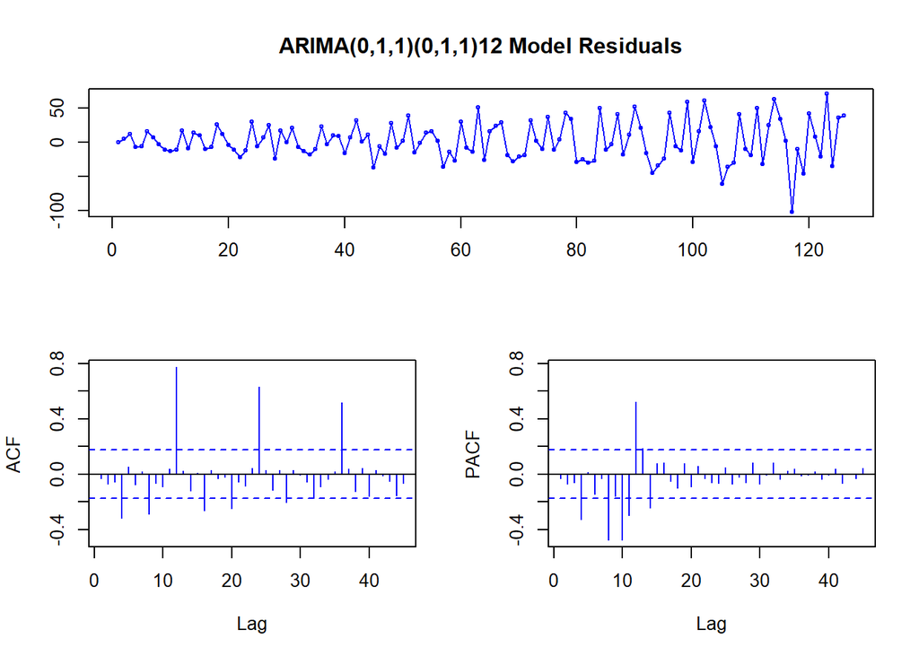

```r
tsdisplay(residuals(tmodel1), lag.max=45,
          main='ARIMA(0,1,1)(0,1,1)12 Model Residuals', col="blue")
```

```r
#Eksplorasi
sisaan.model1 <- tmodel1$residuals
par(mfrow=c(2,2))
car::qqPlot(sisaan.model1)
```

```
## [1] 117 123
```

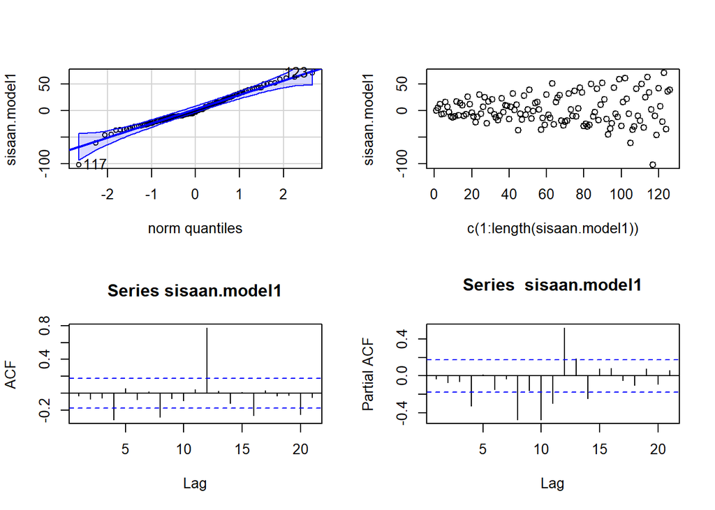

```r
plot(c(1:length(sisaan.model1)),sisaan.model1)
acf(sisaan.model1)
pacf(sisaan.model1)
```

```r
par(mfrow = c(1,1))
```

#### Uji Formal

```r
#1) Sisaan Menyebar Normal
ks.test(sisaan.model1,"pnorm")
```

```
##
##  Asymptotic one-sample Kolmogorov-Smirnov test
##
## data:  sisaan.model1
## D = 0.5031, p-value < 2.2e-16
## alternative hypothesis: two-sided
```

```r
#tak tolak H0 > sisaan menyebar normal
shapiro.test(sisaan.model1)
```

```
##
##  Shapiro-Wilk normality test
##
## data:  sisaan.model1
## W = 0.97827, p-value = 0.04004
```

```r
nortest::ad.test(sisaan.model1)
```

```
##
##  Anderson-Darling normality test
##
## data:  sisaan.model1
## A = 0.76405, p-value = 0.04578
```

Selain dengan eksplorasi, asumsi tersebut dapat diuji menggunakan uji formal. Pada tahapan ini uji formal yang digunakan untuk normalitas adalah uji Kolmogorov-Smirnov (KS), Shapiro-Wilk, dan Anderson-Darling. Hipotesis pada uji kenormalan adalah sebagai berikut.

$H_0$ : Sisaan menyebar normal

$H_1$ : Sisaan tidak menyebar normal

```r
#2) Sisaan saling bebas/tidak ada autokorelasi
Box.test(sisaan.model1, type = "Ljung")
```

```
##
##  Box-Ljung test
##
## data:  sisaan.model1
## X-squared = 0.13807, df = 1, p-value = 0.7102
```

```r
#tak tolak H0 > sisaan saling bebas
```

Selanjutnya akan dilakukan uji formal untuk kebebasan sisaan menggunakan uji Ljung-Box. Hipotesis yang digunakan adalah sebagai berikut.

$H_0$ : Sisaan saling bebas

$H_1$ : Sisaan tidak tidak saling bebas

```r
#3) Sisaan homogen
Box.test((sisaan.model1)^2, type = "Ljung")
```

```
##
##  Box-Ljung test
##
## data:  (sisaan.model1)^2
## X-squared = 0.29354, df = 1, p-value = 0.588
```

```r
#tak tolak H0 > sisaan homogen
```

Hipotesis yang digunakan untuk uji kehomogenan ragam adalah sebagai berikut.

$H_0$ : Ragam sisaan homogen

$H_1$ : Ragam sisaan tidak homogen

```r
#4) Nilai tengah sisaan sama dengan nol
t.test(sisaan.model1, mu = 0, conf.level = 0.95)
```

```
##
##  One Sample t-test
##
## data:  sisaan.model1
## t = 0.89208, df = 125, p-value = 0.3741
## alternative hypothesis: true mean is not equal to 0
## 95 percent confidence interval:
##  -2.689855  7.104717
## sample estimates:
## mean of x
##  2.207431
```

```r
#tak tolak h0 > nilai tengah sisaan sama dengan 0
```

Terakhir, dengan uji-t, akan dicek apakah nilai tengah sisaan sama dengan nol. Hipotesis yang diujikan sebagai berikut.

$H_0$ : nilai tengah sisaan sama dengan 0

$H_1$ : nilai tengah sisaan tidak sama dengan 0

### Overfitting

Pertama, *overfit* pada model non-musimannya (p,q)

```r
#ARIMA(1,1,3)x(1,1,1)12
tmodel1.ofP <- Arima(train.ts,order=c(1,1,3),seasonal=c(1,1,1))
summary(tmodel1.ofP)
```

```
## Series: train.ts
## ARIMA(1,1,3)
##
## Coefficients:
##          ar1      ma1      ma2     ma3
##       0.5747  -0.3102  -0.6121  0.1061
## s.e.  0.1472   0.1557   0.1547  0.1361
##
## sigma^2 = 719.3:  log likelihood = -586.89
## AIC=1183.79   AICc=1184.29   BIC=1197.93
##
## Training set error measures:
##                    ME     RMSE      MAE      MPE     MAPE      MASE        ACF1
## Training set 5.402568 26.28296 21.32335 1.632088 8.307716 0.9425103 -0.06622665
```

```r
lmtest::coeftest(tmodel1.ofP)
```

```
##
## z test of coefficients:
##
##     Estimate Std. Error z value  Pr(>|z|)
## ar1  0.57467    0.14723  3.9031 9.498e-05 ***
## ma1 -0.31021    0.15573 -1.9920   0.04638 *
## ma2 -0.61205    0.15467 -3.9571 7.585e-05 ***
## ma3  0.10612    0.13613  0.7795   0.43567
## ---
## Signif. codes:  0 '***' 0.001 '**' 0.01 '*' 0.05 '.' 0.1 ' ' 1
```

```r
#ARIMA(0,1,2)x(1,1,1)12
tmodel1.ofQ <- Arima(train.ts,order=c(0,1,2),seasonal=c(1,1,1))
summary(tmodel1.ofQ)
```

```
## Series: train.ts
## ARIMA(0,1,2)
##
## Coefficients:
##          ma1      ma2
##       0.3347  -0.3737
## s.e.  0.1035   0.1406
##
## sigma^2 = 757.4:  log likelihood = -591.05
## AIC=1188.09   AICc=1188.29   BIC=1196.58
##
## Training set error measures:
##                    ME     RMSE      MAE       MPE     MAPE      MASE
## Training set 2.799593 27.19128 21.87304 0.6548217 8.634491 0.9668067
##                     ACF1
## Training set -0.01002114
```

```r
lmtest::coeftest(tmodel1.ofQ)
```

```
##
## z test of coefficients:
##
##     Estimate Std. Error z value Pr(>|z|)
## ma1  0.33471    0.10349  3.2342 0.001220 **
## ma2 -0.37367    0.14057 -2.6583 0.007853 **
## ---
## Signif. codes:  0 '***' 0.001 '**' 0.01 '*' 0.05 '.' 0.1 ' ' 1
```

### Peramalan

```r
ramalan_sarima = forecast::forecast(tmodel1, 96)
ramalan_sarima
```

```
##     Point Forecast     Lo 80    Hi 80        Lo 95     Hi 95
## 127       485.6218 449.76874 521.4748  430.7892816  540.4543
## 128       485.6218 425.59215 545.6514  393.8143777  577.4292
## 129       485.6218 408.66937 562.5742  367.9332277  603.3103
## 130       485.6218 394.84849 576.3951  346.7960203  624.4475
## 131       485.6218 382.87011 588.3734  328.4766632  642.7669
## 132       485.6218 372.14922 599.0943  312.0804767  659.1631
## 133       485.6218 362.35728 608.8863  297.1049899  674.1386
## 134       485.6218 353.28791 617.9557  283.2345859  688.0090
## 135       485.6218 344.80143 626.4421  270.2556440  700.9879
## 136       485.6218 336.79810 634.4455  258.0156098  713.2279
## 137       485.6218 329.20374 642.0398  246.4010348  724.8425
## 138       485.6218 321.96140 649.2822  235.3248341  735.9187
## 139       485.6218 315.02625 656.2173  224.7184314  746.5251
## 140       485.6218 308.36222 662.8813  214.5266795  756.7169
```

[output cut: 82 more lines]

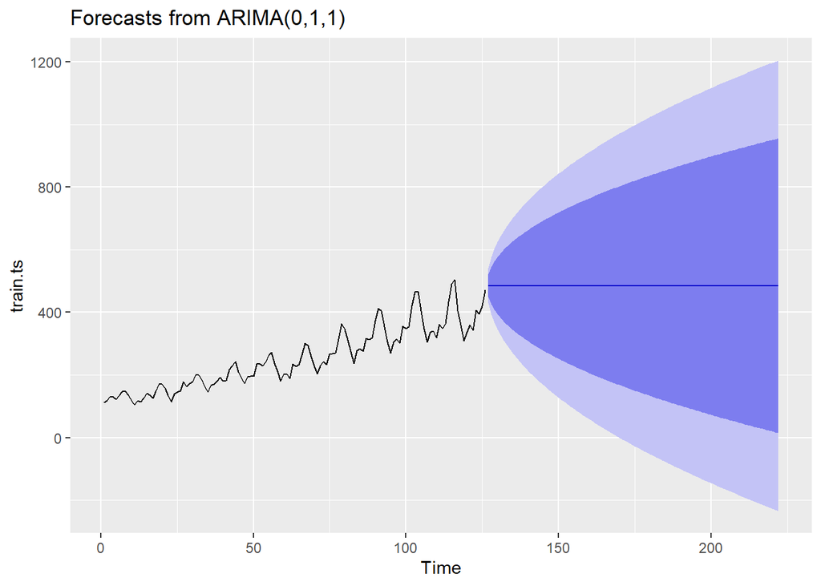

```r
autoplot(ramalan_sarima, col="blue")
```

```r
accuracy(ramalan_sarima,test.ts)
```

```
##                      ME     RMSE      MAE        MPE      MAPE      MASE
## Training set   2.207431 27.75336 21.88912  0.5237371  8.576003 0.9675177
## Test set     -22.055112 90.27702 78.53247 -8.5525989 18.260077 3.4712020
##                     ACF1 Theil's U
## Training set -0.03271205        NA
## Test set      0.09837734 0.7337439
```